# Analysis on the U.S. 10-year Treasury Bond Yied

# 1 Motivation and Background for the analysis

# 2 Basic Plot

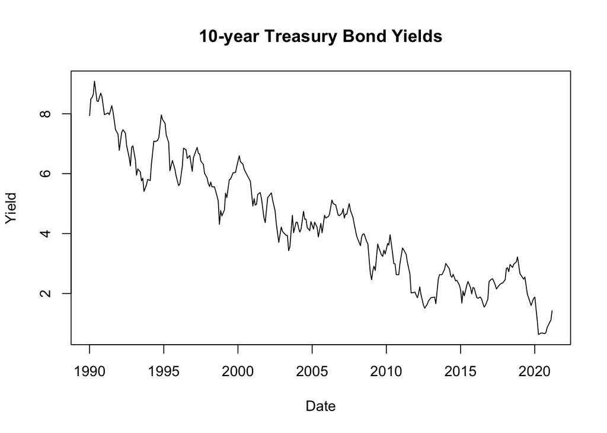

```r
# Generate and plot a monthly data for 10-year Treasury Bond Yields

for (year in 1990:2021) {
  for (month in 1:12) {
    data %>% filter(year==year, month==month)
  }
}

monthdata = data %>% filter(day==2)
plot(Yield~Date, data=monthdata, ty="l", main="10-year Treasury Bond Yields")
```

We can see that there is a downward trend. I first consider to fit ARMA model for this data.

# 3 ARMA: Parameter Estimation and Model Identification

```r
aic_table = function(data,P,Q) {
  table = matrix(NA, (P+1), (Q+1))
  for (p in 0:P) {
    for (q in 0:Q) {
      table[p+1,q+1] = arima(data, order=c(p,0,q))$aic
    }
  }
  dimnames(table) = list(paste("AR", 0:P, sep=""),paste("MA", 0:Q, sep=""))
  table
}
yield = monthdata$Yield
yield = as.numeric(yield)

yield_aic_table = aic_table(yield, 3, 4)
require(knitr)
kable(yield_aic_table, digits=2)
```

|  | MA0 | MA1 | MA2 | MA3 | MA4 |
| --- | --- | --- | --- | --- | --- |
| AR0 | 1099.26 | 806.22 | 601.76 | 492.32 | 403.23 |
| AR1 | 164.55 | 166.47 | 168.37 | 170.25 | 171.47 |
| AR2 | 166.47 | 168.55 | 168.51 | 170.44 | 173.36 |
| AR3 | 168.37 | 169.97 | 166.68 | 168.69 | 172.38 |

According to the table above, ARMA(1,0) model has the lowest AIC. The AR(1) model is of the form $Y_n =\mu+(Y_{n-1}-\mu)+\epsilon_n$, where the $\epsilon_n$ is a white noise process with distribution $N(0, \sigma^2)$. Although the AIC table identifies this model as the most appropriate or the data, we can consider various nearby models which have similar level of AIC values, including the ARMA(1,1), ARMA(2,0) and ARMA(3,2).

|  | Intercept | SE (Intercept) | AR1 Coef. | AR2 Coef. | MA1 Coef. |
| --- | --- | --- | --- | --- | --- |
| ARMA(1,0) | 4.503 | 1.678 | 0.991 | NA | NA |
| ARMA(1,1) | 4.468 | 1.648 | 0.991 | NA | 0.018 |
| ARMA(2,0) | 4.458 | 1.648 | 1.008 | -0.017 | NA |

According to the table above, the MA1 coefficient of ARMA(1,1) and the AR2 coefficient of ARMA(2,0) are very close to zero and don’t seem to be doing anything significantly different from the ARMA(1,0). Then, the ARMA(1,0) model can be written as $Y_{n}=4.503+0.991(Y_{n-1}-4.503)+\epsilon_{n}$.

Next, I examined the roots of the AR model as below. The root is outside the unit circle, suggesting we have a stationary causal fitted ARMA.

```r
polyroot(c(1, -coef(ar1)[c("ar1")]))
```

```
## [1] 1.008931+0i
```

Since I have identified the ARMA(1,0) as the best model for the data, I need to check that the model assumption are valid. First, I will look at the residuals of the fitted ARMA(1,0) model as a time series plot.

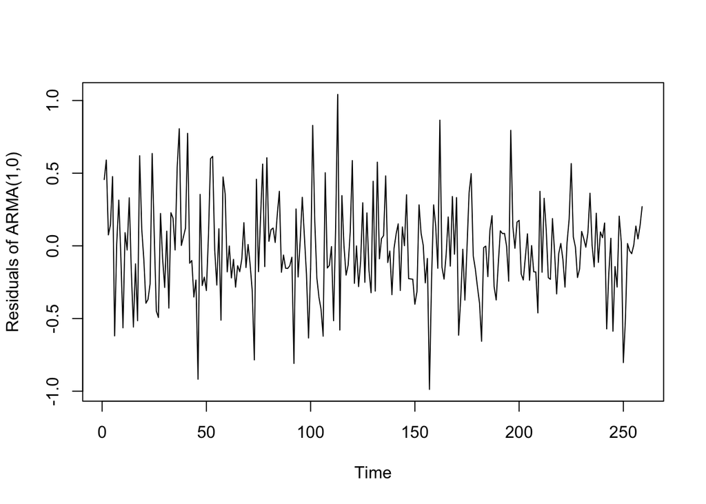

The time series plot shows no striking patterns in the residuals, so I don’t think there is anything too worrisome here. Next, we can draw the ACF plot for the residuals. This will allow us to check our assumption that the errors ${e_n}$ are uncorrelated. There is only two lags with significant autocorrelation (lag 9 and 17), while the rest may be considered sufficiently close to zero. While this may be the case, there are also some potentially non-negligible fluctuations in the autocorrelation that might be interesting to look into more carefully. This results into motivation for the investigating the cycle, which will be discussed later in this report.

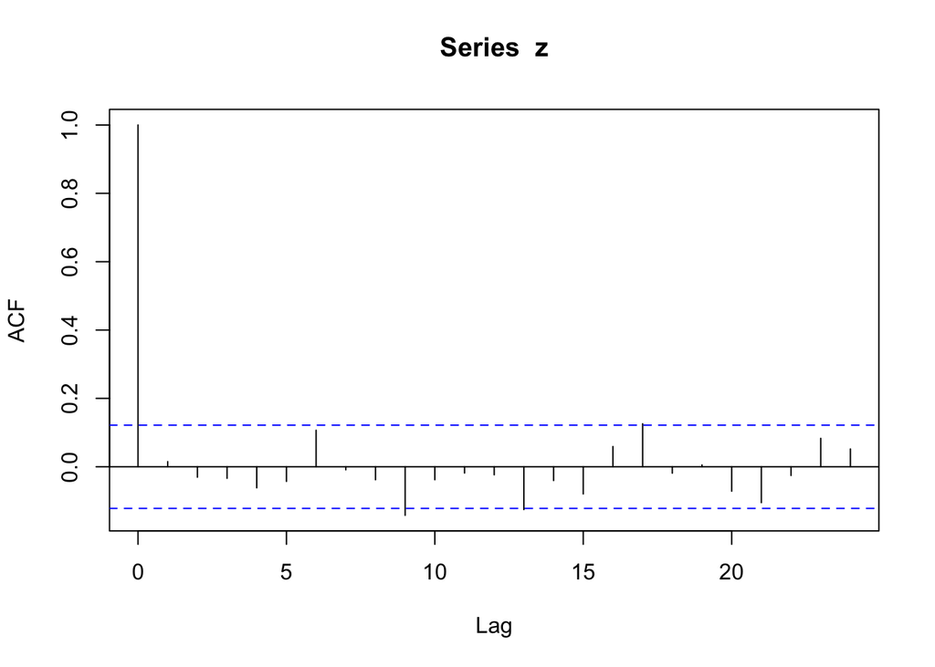

```r
z = arima(yield, order=c(1,0,0))$residuals
acf(z)
```

Finally, in fitting an ARMA model, we make the assumption that {$\epsilon_n$}$\sim N(0,\sigma^2)$ and we can check the normality assumption with a QQ-plot of the residuals. The residuals do not seem to be normal to make this assumption valid. This suggests that there might be another model that better fits for this data. One possible solution here may be to conduct furtehr analysis on the cyclic pattern, which results into the investigation in the frequency domain.

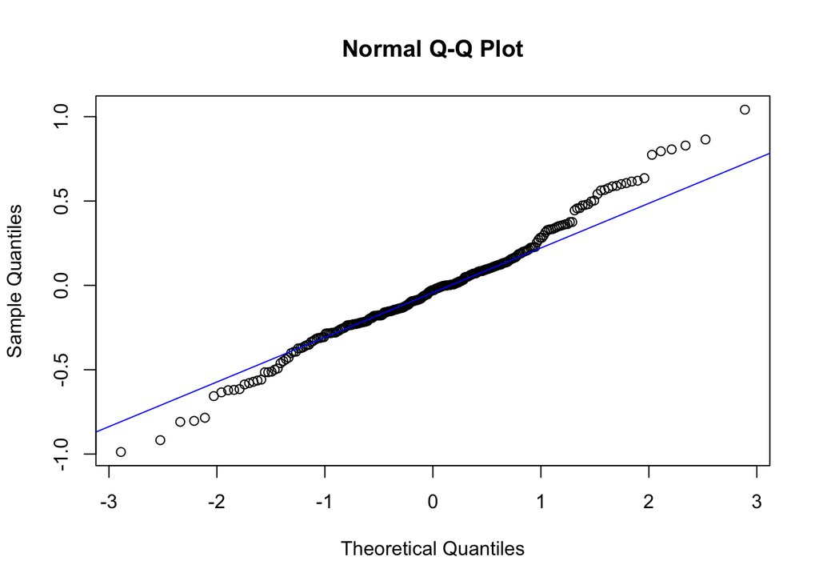

# 4 Frequency domain data analysis

Let’s figure out the frequency domain. First, I plot the smoothed periodogram.

```r
smoothed_r = spectrum(yield, spans=c(5,5), main="Smoothed periodogram")
```

[figure not shown]

```r
dom_freq = smoothed_r$freq[which.max(smoothed_r$spec)]
dom_period = 1/dom_freq
dom_freq; dom_period
```

```
## [1] 0.02222222
```

```
## [1] 45
```

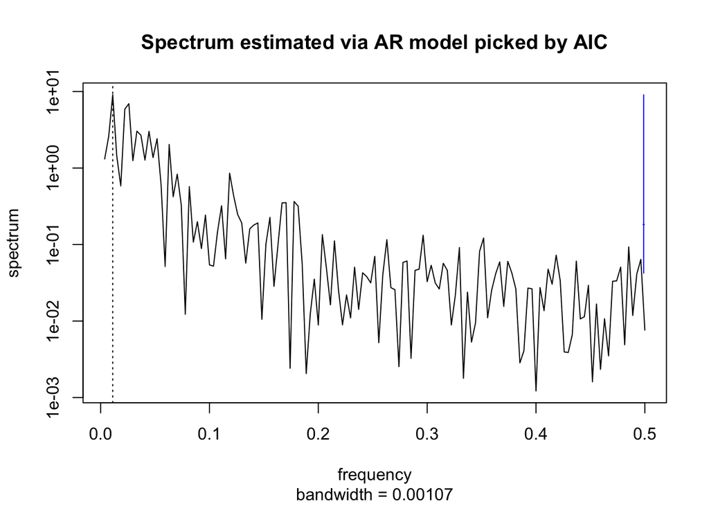

```r
estimated = spectrum(yield, main="Spectrum estimated via AR model picked by AIC")
abline(v=estimated$freq[which.max(estimated$spec)], lty="dotted")
```

```r
estimated$freq[which.max(estimated$spec)]
```

```
## [1] 0.01111111
```

```r
1/estimated$freq[which.max(estimated$spec)]
```

```
## [1] 90
```

# 5 Conclusion

- The 10-year US Treasury Bond yield has a trend, and it is well explained by the ARMA(1,0) model. However, the ARMA model also suggests to try other methods due to the lack of normality for the error term.
- The 10-year Treasury yield has kept moving downward since 1990. Since there is not much room below the current level, it may be interesting to think about and predict the future long-term trend for the yield.
- If we focus on the recent time period after 2020, it seems that the yield started to increase. We may be able to pay attention to the future short-term change to see whether this upward movement is consistent with the cyclic pattern that I found in my analysis in the frequency domain.
- For the final project, I will extend the research to investigate the association with the other data. The candidates are unemployment rates and the PMI (Purchasing Managers’ Index).

# 6 Reference

[1] 10-year U.S. Treasury Bond Yield data

https://www.treasury.gov/resource-center/data-chart-center/interest-rates/Pages/TextView.aspx?data=yield

[2] Introduction to Risk-Based Capital (RBC) by National Association of Insurance Commissioners

https://content.naic.org/cipr_topics/topic_riskbased_capital.htm

[3] Parsing 10-year federal note yield from the website

https://stackoverflow.com/questions/37952589/parsing-10-year-federal-note-yield-from-the-website

[4] Prof. Edward Ionides’ Lecture Slides for STATS 531 (Winter 2021)

https://ionides.github.io/531w21/#class-notes-and-lectures